# final_R_reference.Rmd

Hannah Korte

12/10/2021

# Loading data and Packages

## library() and require()

The Library() function loads packages that have already been installed within an environment or loads packages that come installed with R.

```r
library(here)
library(palmerpenguins)
```

The require() function does that same thing as library().

```r
require(here)
require(palmerpenguins)
```

## here() and read.csv()

The here() function tells R to look for data that is in a specific “directory” or path within a projects environment.

The read.csv() function allows R to read and convert a .csv file into a data frame.

```r
ginkgo = read.csv(here("data","ginkgo_data_2021.csv"))
```

# Data Structures

## c()

The function c() combines or concatenates its arguments into a vector (a 1-dimensional data structure consisting of 1 or more elements).

- All of the elements must be of the same type.
  - I can’t combine character and numeric types in the same call to c().

Here’s two examples using numeric and character data types:

```r
## Create a vector of numbers:
num_vec  = c(1, 4, 8, 9, 13)

## Create a vector of characters:
char_vec = c("a", "fish", "data is cool")
```

I can show the contents of a vector by typing the name of the vector, or using the print() function.

```r
## Typing the name of the vector into the console prints the contents
num_vec
```

```
## [1]  1  4  8  9 13
```

```r
## The print() function accomplishes the same task:
print(char_vec)
```

```
## [1] "a"            "fish"         "data is cool"
```

## length()

The function length() retrieves or sets the length of vectors, factors, or any R object where a method has been defined.

Here’s an example:

```r
length(penguins)
```

```
## [1] 8
```

## matrix()

The function matrix() creates a matrix from a given series of values.

- If either nrow or ncol are not given, an attempt is made to interpret it from the length of data and the other parameter.
- If neither is given, it returns a one-column matrix.

Here’s an example:

```r
my_matrix = matrix(data = 1:9, nrow = 3, ncol = 3)
## Sum of elements in the matrix
sum(my_matrix)
```

```
## [1] 45
```

## data.frame()

The function data.frame() generates tightly coupled sets of varaibles that share many of the properties of matrices and lists. For most of R’s modeling software it is used as the fundamental data structure.

Here’s an example:

```r
mat_dat= data.frame(my_matrix, row.names = c("A", "B","C"))

setNames(mat_dat, c("H1", "H2", "H3"))
```

```
##   H1 H2 H3
## A  1  4  7
## B  2  5  8
## C  3  6  9
```

- The function nrow() returns the number of rows in a dataframe.

```r
nrow(ginkgo)
```

```
## [1] 756
```

- The function ncol() returns the number of columns in a dataframe.

```r
ncol(ginkgo)
```

```
## [1] 6
```

- The function dim() returns that dimensions of a dataframe, which is both columns and rows.

```r
dim(ginkgo)
```

```
## [1] 756   6
```

# Subsetting

Subsetting allows you to select and/or exclude variables or parts of a data frame.

## $

This subsets a data frame by name.

```r
ginkgo$max_depth
```

```
##   [1]  40  38  32  40  40  50  42  35  45  37  41  42  50  46  46  46  42  43
##  [19]  44  37  46  45  51  40  36  37  40  57  58  46  53  64  45  64  56  55
##  [37]  55  60  40  43  59  55  49  60  45  58  53  38  56  68  53  55  59  54
##  [55]  52  39  59  60  51  62  41  53  50  33  31  51  58  51  57  57  49  45
##  [73]  49  39  40  49  47  49  55  46  40  38  32  40  40  50  42  35  45  37
##  [91]  41  42  50  46  46  46  42  43  44  37  46  45  51  40  36  37  40  55
## [109]  46  37  43  50  56  58  48  55  46  45  54  67  41  45  55  54  40  45
## [127]  36  48  55  55  54  34  50  42  49  55 105 109 145 111  95  91  94  85
## [145] 138 121 110 127 108 100  96  97  97 104  93  87  69 102  70  97  98 103
## [163]  95  94  96 104 107  75 105  82  89 106 115  87  55  41  49  57  41  45
## [181]  56  60  53  41  40  42  47  51  51  43  49  58  56  41  68  50  55  44
## [199]  38  39  32 104  71 120 109  90  93  66  72  84  80 103  80  65  85  90
## [217]  62  92  71  89  95  80  55  55  38  23  41  40  47  58  87 100  91 111
## [235] 106 106 100 113  98 103  93  79  85  95  62 103  80  78  89  84 108  79
## [253] 111 106 100  67 105 108  81 127 110  88  97  85  85 106  92 113 125  70
```

[output cut: 27 more lines]

## []

This subsets by position.

```r
ginkgo[1,]
```

```
##   site_id seeds_present max_width max_depth notch_depth petiole_length
## 1    7719         FALSE        71        40           0             30
```

```r
ginkgo[2,3]
```

```
## [1] 64
```

```r
ginkgo[,3]
```

```
##   [1]  71.0  64.0  55.0  62.0  65.0  70.0  63.0  56.0  51.0  57.0  59.0  63.0
##  [13]  70.0  50.0  56.0  46.0  54.0  62.0  56.0  55.0  59.0  60.0  63.0  61.0
##  [25]  58.0  55.0  53.0  81.0  94.0  75.0  82.0  86.0  79.0  93.0  88.0  76.0
##  [37]  71.0  91.0  71.0  82.0  65.0  83.0  73.0 102.0  78.0  88.0  81.0  70.0
##  [49]  80.0  96.0  80.0  82.0  86.0  87.0  89.0  69.0  93.0  98.0  81.0  79.0
##  [61]  82.0  85.0  81.0  59.0  53.0  83.0  80.0  77.0  81.0  76.0  82.0  81.0
##  [73]  77.0  68.0  41.0  70.0  68.0  80.0  89.0  90.0  71.0  64.0  55.0  62.0
##  [85]  65.0  70.0  63.0  56.0  51.0  57.0  59.0  63.0  70.0  50.0  56.0  46.0
##  [97]  54.0  62.0  56.0  55.0  59.0  60.0  63.0  61.0  58.0  55.0  53.0  77.0
## [109]  72.0  57.0  75.0  75.0  75.0  67.0  74.0  71.0  72.0  55.0  77.0  97.0
## [121]  73.0  64.0  69.0  92.0  64.0  68.0  53.0  97.0 100.0  90.0  89.0  59.0
## [133]  97.0  76.0  85.0  90.0  87.0  85.0  80.0  86.0  89.0  84.0  88.0  80.0
## [145] 102.0  94.0  95.0 109.0  84.0  68.0  59.0  74.0  70.0  71.0  69.0  74.0
## [157]  70.0  78.0  87.0  69.0  60.0  72.0  59.0  75.0  81.0  82.0  74.0  72.0
## [169]  79.0  84.0  75.0  72.0  88.0  80.0  90.0  58.0  61.0  95.0  72.0  90.0
```

[output cut: 48 more lines]

## subset()

This function is used to subset matrices, vectors or data frames that meet certain conditions.

```r
require(palmerpenguins)
penguins=penguins
subset(penguins, species= "Adelie")
```

```
## # A tibble: 344 x 8
##    species island bill_length_mm bill_depth_mm flipper_length_… body_mass_g
##    <fct>   <fct>           <dbl>         <dbl>            <int>       <int>
##  1 Adelie  Torge…           39.1          18.7              181        3750
##  2 Adelie  Torge…           39.5          17.4              186        3800
##  3 Adelie  Torge…           40.3          18                195        3250
##  4 Adelie  Torge…           NA            NA                 NA          NA
##  5 Adelie  Torge…           36.7          19.3              193        3450
##  6 Adelie  Torge…           39.3          20.6              190        3650
##  7 Adelie  Torge…           38.9          17.8              181        3625
##  8 Adelie  Torge…           39.2          19.6              195        4675
##  9 Adelie  Torge…           34.1          18.1              193        3475
## 10 Adelie  Torge…           42            20.2              190        4250
## # … with 334 more rows, and 2 more variables: sex <fct>, year <int>
```

# Numerical Data Exploration

## summary()

The function summary() is used to display summary statistics of data frames.

```r
summary(penguins)
```

```
##       species          island    bill_length_mm  bill_depth_mm
##  Adelie   :152   Biscoe   :168   Min.   :32.10   Min.   :13.10
##  Chinstrap: 68   Dream    :124   1st Qu.:39.23   1st Qu.:15.60
##  Gentoo   :124   Torgersen: 52   Median :44.45   Median :17.30
##                                  Mean   :43.92   Mean   :17.15
##                                  3rd Qu.:48.50   3rd Qu.:18.70
##                                  Max.   :59.60   Max.   :21.50
##                                  NA's   :2       NA's   :2
##  flipper_length_mm  body_mass_g       sex           year
##  Min.   :172.0     Min.   :2700   female:165   Min.   :2007
##  1st Qu.:190.0     1st Qu.:3550   male  :168   1st Qu.:2007
##  Median :197.0     Median :4050   NA's  : 11   Median :2008
##  Mean   :200.9     Mean   :4202                Mean   :2008
##  3rd Qu.:213.0     3rd Qu.:4750                3rd Qu.:2009
##  Max.   :231.0     Max.   :6300                Max.   :2009
##  NA's   :2         NA's   :2
```

## mean()

The function mean() returns the mean of a numerical dataset.

- For datasets with many observations, you must specify a numeric subset for this function to work.
- This function will not work if the data set includes NA values. When using a data set that includes NAs, you have to add the “na.rm = TRUE” argument so R will remove all NA values.

```r
mean(penguins$bill_length_mm, na.rm=T)
```

```
## [1] 43.92193
```

## sd()

The function sd() returns the standard deviation from the mean of a numeric data set.

- Just like with mean you must specify the subset you want to be able to use this function

```r
sd(penguins$bill_length_mm, na.rm=T)
```

```
## [1] 5.459584
```

# Graphical Data Exploration

## Scatterplot

- Plot() creates a scatterplot of data using any combination of the arguments below:
  - x and y: Specify the data being plotted
  - col: Specifies the color of the plotted points.
  - pch: Its an integer that specifies the symbol type for the points.
  - cex: Specifies the size of the points in the plot.
  - main: Sets the title for the plot
  - xlab: Sets the x-axis lable
  - ylab: Sets the y-axis lable
  - xlim: Sets the minimum & maximum x-axis values.
  - ylim: Sets the minimum & maximum y-axis values.

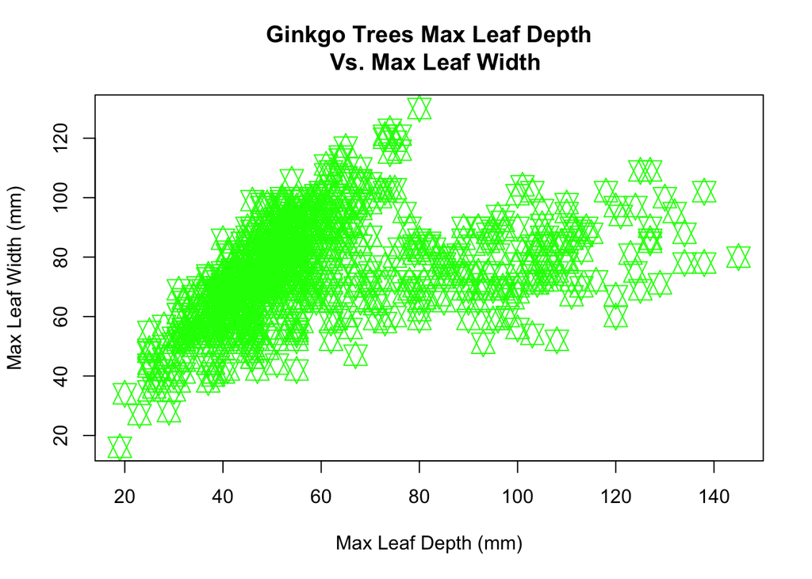

```r
#scatterplot of max leaf depth and max leaf width
plot(
  x=ginkgo$max_depth,
  y=ginkgo$max_width,
  col= "green",
  pch= 11,
  cex= 2,
  main= "Ginkgo Trees Max Leaf Depth
  Vs. Max Leaf Width",
  xlab = "Max Leaf Depth (mm)",
  ylab = "Max Leaf Width (mm)",
  xlim=c(19,145),
  ylim=c(16,130)
)
```

## Histogram

- The hist() function creates a histogram of a specified data set.

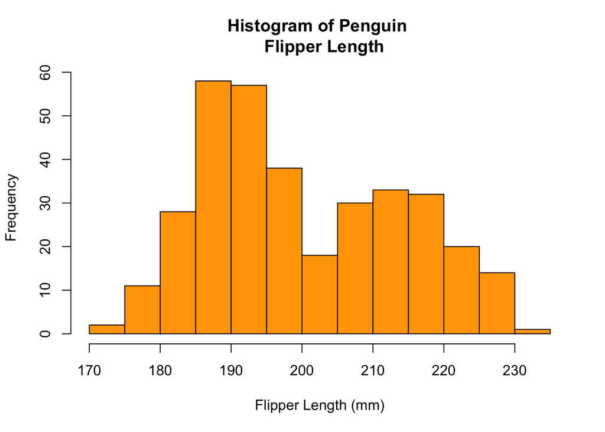

```r
#Histogram of penghin flipper lengths
hist(
  penguins$flipper_length_mm,
  main= "Histogram of Penguin
  Flipper Length",
  xlab= "Flipper Length (mm)",
  breaks= 20,
  col= "orange"
)
```

## Boxplot

- The boxplot() function creates box-and-whisker plots of data sets.

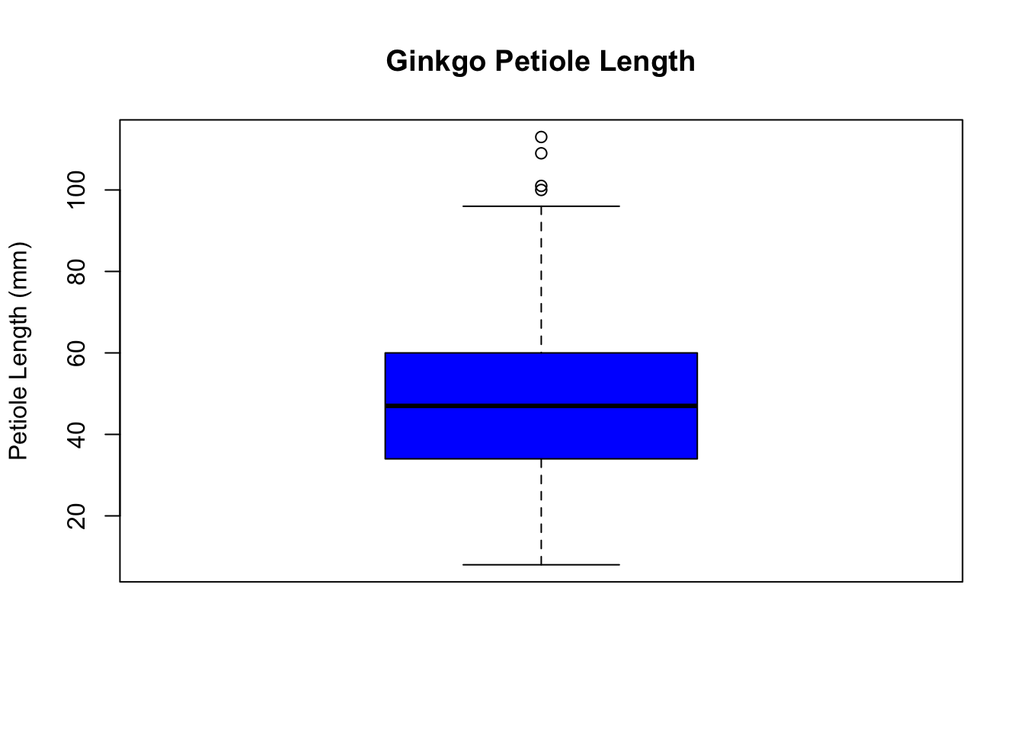

```r
#Simple boxplot of ginkgo petiole lengths
boxplot(ginkgo$petiole_length,
 col= "blue",
 main= "Ginkgo Petiole Length",
 ylab= "Petiole Length (mm)")
```

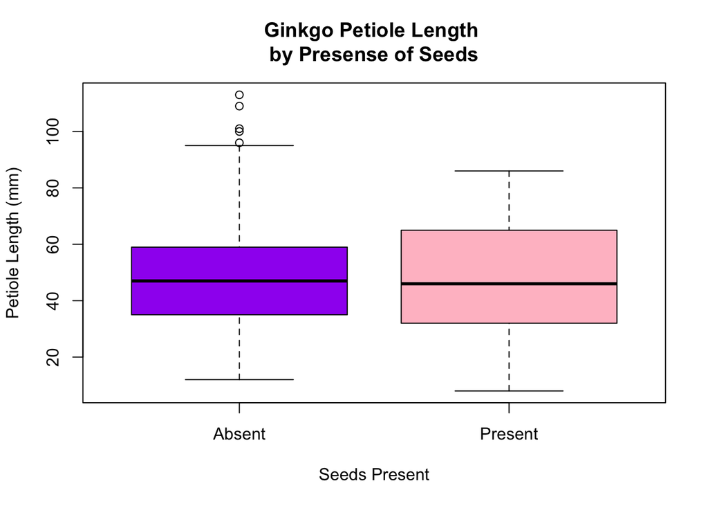

```r
#Conditional boxplot of one of the continuous variables conditioned on the seeds_present column.
boxplot(ginkgo$petiole_length ~ ginkgo$seeds_present,
col= c("purple", "pink"),
main= "Ginkgo Petiole Length
by Presense of Seeds",
xlab= "Seeds Present",
ylab= "Petiole Length (mm)",
names= c("Absent", "Present"))
```

## 4-Panel Figure

- Using par(mfrow=) allows us to specify the number of figures in each row and column.

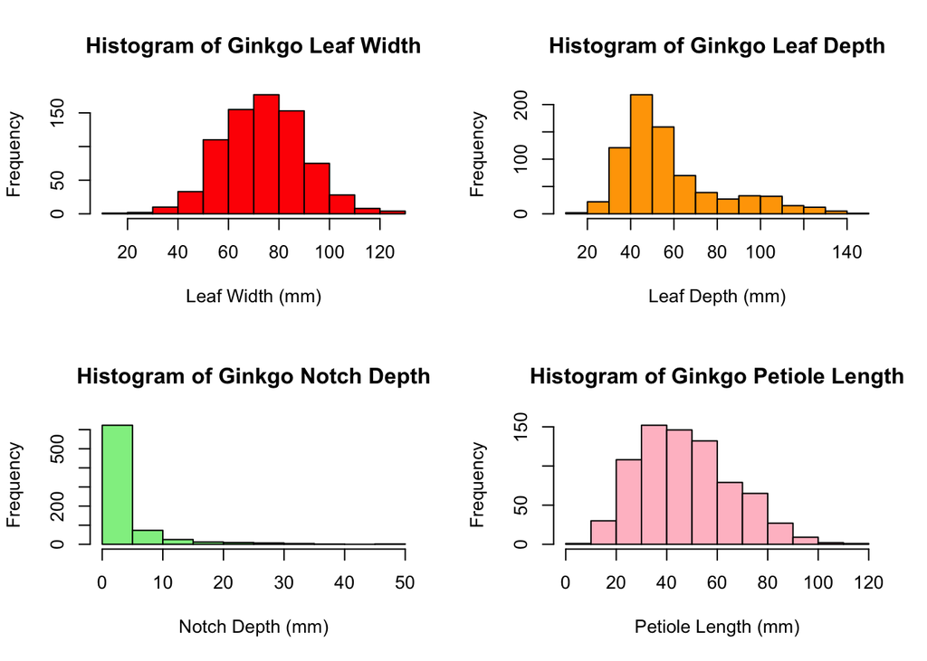

```r
par(mfrow=c(2,2))

 hist(
    ginkgo$max_width,
    main = "Histogram of Ginkgo Leaf Width",
    xlab = "Leaf Width (mm)",
    col = "red"
  )

  hist(
    ginkgo$max_depth,
    main = "Histogram of Ginkgo Leaf Depth",
    xlab = "Leaf Depth (mm)",
    col = "orange"
  )

  hist(
    ginkgo$notch_depth,
    main = "Histogram of Ginkgo Notch Depth",
    xlab = "Notch Depth (mm)",
    col = "lightgreen"
  )

  hist(
    ginkgo$petiole_length,
    main = "Histogram of Ginkgo Petiole Length",
    xlab = "Petiole Length (mm)",
    col = "pink"
  )
```

# Distribution Functions

Distribution functions are used with a set of observed data to answer questions about the probability of certain outcomes.

- There are two types of distributions we have worked with in class:
  - Normal Distribution: This is when a data set follows a bell-shaped curve where the data close to the mean occur more frequently than data far from the mean.
  - Binomial Distribution: This is a discrete type of data set in which there can only be two possible outcomes. The data is acquired through reapeted trials, where one of the two outcomes is recorded.

## dnorm()

- Probability density function for a normal distribution

```r
dnorm(x=2, mean=5, sd=1)
```

```
## [1] 0.004431848
```

## pnorm()

- Cumulative distribution function for a normal distribution.

```r
pnorm(q=2,mean=7,sd=1)
```

```
## [1] 2.866516e-07
```

## qnorm()

- Quantile function for a normal distribution.

```r
qnorm(p=0.85,mean=70,sd=3)
```

```
## [1] 73.1093
```

## dbinom()

- Probability density function for a binomial distribution.

```r
dbinom(x=5, size=100, prob=0.5)
```

```
## [1] 5.939138e-23
```

## pbinom()

- Cumulative distribution function for a binomial distribution.

```r
pbinom(q=5, size=100, prob=0.5)
```

```
## [1] 6.261623e-23
```

## qbinom()

- Quantile function for a binomial distribution.

```r
qbinom(p=0.3, size=100, prob=0.5)
```

```
## [1] 47
```